# Równanie Schrödingera - Analiza Numeryczna

*Julia Zalewska, Oliwia Marut, Natalia Chmiel*

## Wprowadzenie

Równanie Schrödingera jest fundamentalnym równaniem w mechanice kwantowej, opisującym ewolucję funkcji falowej cząstki. Jest to liniowe równanie różniczkowe cząstkowe rzędu pierwszego względem czasu i rzędu drugiego względem przestrzeni. Równanie opisuje, jak stan kwantowy układu zmienia się w czasie, co pozwala na przewidywanie zachowania cząstek na poziomie kwantowym.

## Model Matematyczny

Równanie Schrödingera dane jest wzorem:

$$i\hbar \frac{\partial}{\partial t} \Psi(x,t) = \left[ -\frac{\hbar^2}{2m} \frac{\partial^2}{\partial x^2} + V(x,t) \right] \Psi(x,t)$$ $$i\hbar \frac{\partial}{\partial t} \Psi(x,t) = \hat{H} \Psi(x,t)$$

gdzie:

- $i$ to jednostka urojona (dzięki niej rozwiązanie ma charakter falowy),
- $\hbar$ to zredukowana stała Plancka,
- $\Psi(x,t)$ to funkcja falowa,
- $m$ to masa cząstki,
- $V(x,t)$ to potencjał działający na cząstkę,
- $\hat{H}$ to operator Hamiltona, reprezentujący całkowitą energię układu.

## Funkcja falowa

W mechanice kwantowej nie znamy dokładnej trajektorii cząstki, dlatego używamy funkcji falowej $\Psi(x,t)$, która zawiera informacje o stanie kwantowym cząstki. Funkcja falowa jest zespolona, a jej moduł kwadratowy $|\Psi(x,t)|^2$ daje gęstość prawdopodobieństwa znalezienia cząstki w określonym miejscu i czasie. Oznacza to, że im większa wartość $|\Psi(x,t)|^2$, tym większe prawdopodobieństwo znalezienia cząstki w danym obszarze przestrzeni. Funkcja falowa zawiera informacje o wszystkich możliwych stanach układu i jest podstawą do obliczania energii czy pędu.

## Potencjał

Potencjał $V(x, t)$ reprezentuje siły działające na cząstkę. W mechanice kwatnowej reprezentuje on energię potencjalną układu. Potencjał może być funkcją zarówno przestrzeni, jak i czasu, co pozwala na modelowanie różnych sytuacji fizycznych. Może on przyjmować różne formy, takie jak potencjał studni, potencjał barierowy czy potencjał harmoniczny. W zależności od kształtu potencjału, funkcja falowa będzie miała różne właściwości i będzie opisywać różne stany kwantowe.

## Założenia modelu matematycznego

Zakładamy, że:

- potencjał $V(x,t)$ jest stały w czasie (środowisko jest stacjonarne), czyli $V(x,t) = V(x)$,
- funkcja falowa $\Psi(x,t)$ może być rozdzielona na część zależną od czasu i część zależną od przestrzeni, czyli $\Psi(x,t) = \Psi(x) \cdot \phi(t)$,
- warunki brzegowe oraz początkowe są dobrze określone, oś x ograniczam do przedziału $[0, L]$ i zakładam, że funkcja falowa jest zerowa na brzegach tego przedziału (warunki Dirichleta),
- unitarność i ciągłość funkcji falowej, zatem $\int_0^L |\Psi(x,t)|^2 dx = 1$

## Przekształcenie modelu matematycznego

$$i\hbar \frac{\partial}{\partial t} \Psi(x,t) = \left[ -\frac{\hbar^2}{2m} \frac{\partial^2}{\partial x^2} + V(x) \right] \Psi(x,t)$$

$$\iff i\hbar \frac{\partial}{\partial t} [\Psi(x) \cdot \phi(t)] = \left[ -\frac{\hbar^2}{2m} \frac{\partial^2}{\partial x^2} + V(x) \right] [\Psi(x) \cdot \phi(t)]$$

$$\iff i\hbar \cdot \Psi(x) \frac{\partial \phi(t)}{\partial t} = \left[ -\frac{\hbar^2}{2m} \frac{\partial^2 \Psi(x)}{\partial x^2} + V(x)\Psi(x) \right] \phi(t) \quad \Bigg| : \big(\Psi(x) \cdot \phi(t)\big)$$

$$\iff i\hbar \frac{1}{\phi(t)} \frac{\partial \phi(t)}{\partial t} = \frac{1}{\Psi(x)} \left[ -\frac{\hbar^2}{2m} \frac{\partial^2 \Psi(x)}{\partial x^2} + V(x)\Psi(x) \right]$$

Zauważmy, że lewa strona równania zależy tylko od czasu, a prawa strona zależy tylko od przestrzeni. Oznacza to, że obie strony muszą być równe tej samej stałej, którą oznaczymy jako $E$ (energia układu):

$$ \begin{cases} \displaystyle i\hbar \frac{1}{\phi(t)} \frac{d\phi(t)}{dt} = E \\[15pt] \displaystyle \frac{1}{\Psi(x)} \left[ -\frac{\hbar^2}{2m} \frac{d^2\Psi(x)}{dx^2} + V(x)\Psi(x) \right] = E \end{cases} $$

Stąd otrzymujemy równanie, na którym się skupimy: $$\frac{1}{\Psi(x)} \left[ -\frac{\hbar^2}{2m} \frac{d^2}{dx^2} + V(x) \right] = E \quad \Bigg| \cdot \big(\Psi(x)\big)$$

$$\iff [-\frac{\hbar^2}{2m} \frac{d^2 \Psi(x)}{dx^2} + V(x)]\Psi(x) = E \cdot \Psi(x)$$

Ostateczne otrzymujemy równanie Schrödingera w postaci stacjonarnej: $\hat{H} \Psi(x) = E \Psi(x)$ Mając powyższe równanie szukamy wartości własnych $E$ (reprezentujących dozwolone energie) i wektorów własnych $\Psi(x)$ operatora Hamiltona. To pozwoli nam zrozumieć stany energetyczne układu kwantowego.

## Przykład analityczny - potencjał studni

Najprostszym przypadkiem jest potencjał studni, gdzie $$V(x) = \begin{cases} 0 & \text{dla } 0 < x < L \\ \infty & \text{dla } x \le 0 \text{ oraz } x \ge L \end{cases}$$ Oznacza to, że cząstka jest ograniczona do poruszania się w przedziale $[0, L]$ i nie może przekroczyć tych granic. Wewnątrz studni potencjał jest równy zero, więc równanie Schrödingera upraszcza się do: $$-\frac{\hbar^2}{2m} \frac{d^2 \Psi(x)}{dx^2} = E \cdot \Psi(x) \quad \Bigg| \cdot \big(-\frac{2m}{\hbar^2})$$ $$\frac{d^2\Psi(x)}{dx^2} + \frac{2mE}{\hbar^2}\Psi(x) = 0$$ Rozwiązaniem tego równania jest funkcja sinusoidalna: $$\Psi(x) = A \sin(kx) + B \cos(kx)$$ gdzie $k = \sqrt{\frac{2mE}{\hbar^2}}$.

Z warunków brzegowych mamy: $$\Psi(0) = 0 \implies B = 0$$ $$\Psi(L) = 0 \implies A \sin(kL) = 0 \implies kL = n\pi, \quad n = 1, 2, 3, ...$$ Stąd otrzymujemy rozwiązanie: $$\Psi_n(x) = \sqrt{\frac{2}{L}} \sin\left(\frac{n\pi x}{L}\right)$$ oraz odpowiadające im energie: $$E_n = \frac{n^2 \pi^2 \hbar^2}{2mL^2}$$

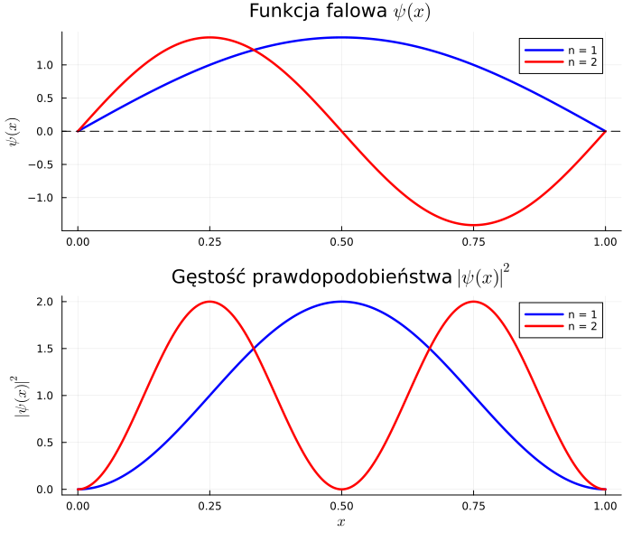

## Przejście do analizy numerycznej — kiedy analityka zawodzi

Przykład ze studnią działał, bo potencjał był idealny: $V(x) = 0$ wewnątrz, symetryczny, bez żadnych nieregularności.

W rzeczywistych problemach — struktury półprzewodnikowe, bariery kwantowe, atomy wieloelektronowe — potencjał $V(x)$ przybiera skomplikowane formy i **rozwiązanie analityczne nie istnieje**.

Musimy zastąpić ciągłe równanie jego dyskretnym odpowiednikiem. Ale to wymaga założeń — i każde z nich może się posypać.

## Założenie A — Siatka musi być wystarczająco gęsta

$$\Delta x = \frac{L}{N-1}, \qquad N \gg 10n$$

**Co się psuje:** przy za małym $N$ siatka nie „widzi" maksimów funkcji — energia błędna, $\Psi$ kancista.

#### Testujemy stan n=5 przy różnych N — od katastrofalnego do dobrego

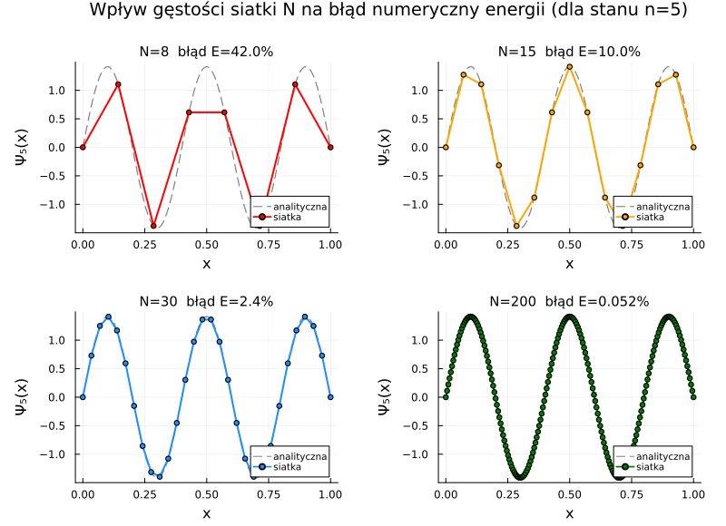

## Założenie B — Normalizacja: norma $\ell^2$ ≠ norma całkowa

Fizyczny warunek $\int_0^L |\Psi|^2\,dx = 1$ zastępujemy dyskretnie regułą trapezów:

$$\sum_{i=1}^{N} |\Psi_i|^2 \,\Delta x \approx 1$$

**Co może pójść źle:** `eigen()` w Julii zwraca wektory znormalizowane w sensie $\ell^2$ (suma kwadratów = 1), **nie** w sensie całkowym. Różnica wynosi czynnik $\sim 1/\Delta x$ — dla $N = 1000$ to błąd rzędu tysiąckrotnego.

[output not shown]

## Algorytm 1 — Metoda Różnic Skończonych (FDM)

Przybliżamy drugą pochodną centralnym ilorazem różnicowym:

$$\frac{d^2\Psi_i}{dx^2} \approx \frac{\Psi_{i+1} - 2\Psi_i + \Psi_{i-1}}{\Delta x^2} + O(\Delta x^2)$$

Równanie $\hat{H}\Psi = E\Psi$ staje się **macierzowym zagadnieniem własnym** $H\mathbf{\Psi} = E\mathbf{\Psi}$, gdzie $H$ jest macierzą trójprzekątniową:

$$H_{ii} = \frac{\hbar^2}{m\Delta x^2} + V(x_i), \qquad H_{i,i\pm1} = -\frac{\hbar^2}{2m\Delta x^2}$$

**Złożoność:**

- Solver gęsty (pełny QR): $O(N^3)$ — dla $N = 10^4$ to $10^{12}$ operacji
- `SymTridiagonal` + Krylov/Lanczos: $O(N \cdot k)$, gdzie $k$ = liczba szukanych stanów

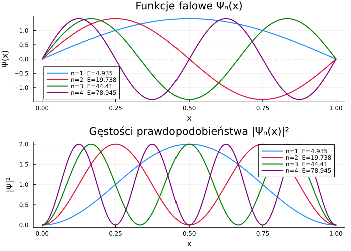

## Algorytm 2 — Metoda Numerowa: $O(\Delta x^4)$ zamiast $O(\Delta x^2)$

Dla równań postaci $\Psi'' = f(x)\Psi$ istnieje dedykowana metoda uwzględniająca wyższe wyrazy rozwinięcia Taylora:

$$\Psi_{i+1}\!\left(1 + \tfrac{\Delta x^2}{12}f_{i+1}\right) = 2\Psi_i\!\left(1 - \tfrac{5\Delta x^2}{12}f_i\right) - \Psi_{i-1}\!\left(1 + \tfrac{\Delta x^2}{12}f_{i-1}\right)$$

Energię własną szukamy bisekcją: propagujemy $\Psi$ od lewego brzegu dla danego $E$ i szukamy $E$ takich że $\Psi(L) = 0$.

| Metoda | Rząd | $N$ potrzebne do błędu $10^{-6}$ |
| --- | --- | --- |
| FDM | $O(\Delta x^2)$ | $N \approx 1000$ |
| Numerov | $O(\Delta x^4)$ | $N \approx 30$ |

**Alternatywy:** metoda elementów skończonych (FEM), metoda spektralna, metoda strzału.

```
numerov_shoot (generic function with 1 method)
```

```
solve_Numerov (generic function with 1 method)
```

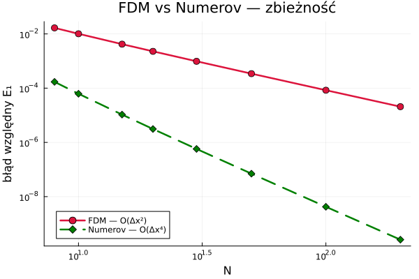